# Poisson Regression

## Key Ideas

- Many data take the form of counts
  - Calls to a call center
  - Number of flu cases in an area
  - Number of cars that cross a bridge
- Data may also be in the form of rates
  - Percent of children passing a test
  - Percent of hits to a website from a country
- Linear regression with transformation is an option

## Poisson Distribution

- The Poisson distribution is a useful model for counts and rates
- Here a rate is count per some monitoring time
- Some example uses of the Poisson distribution
  - Modeling web traffic hits
  - Incidence rates
  - Approximating binomial probabilities with small $p$ and large $n$
  - Analyzing contingency table data

## The Poisson Mass Function

- $X \sim Poisson(t\lambda)$ if
  $$P(X = x) = \frac{(t\lambda)^x e^{-t\lambda}}{x!}$$
  for $x = 0,1,...$
- The mean of the Poisson is $E[X] = t\lambda$, thus $E[X/t] = \lambda$
- The variance of the Poisson is $Var(X) = t\lambda$
- The Poisson tends to a normal as $t\lambda$ gets large

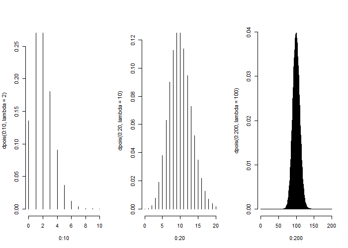

```r
par(mfrow=c(1,3))
plot(0:10, dpois(0:10, lambda=2), type="h", frame=F)
plot(0:20, dpois(0:20, lambda=10), type="h", frame=F)
plot(0:200, dpois(0:200, lambda=100), type="h", frame=F)
```

## Poisson Distribution

#### Sort of, showing that the mean and the variance are equal

```r
x <- 0:10000
lambda <- 3
mu <- sum(x * dpois(x, lambda=lambda))
sigmasq <- sum((x - mu)^2 * dpois(x, lambda=lambda))
c(mu, sigmasq)
```

```
[1] 3 3
```

## Example: Leek Group Website Traffic

- Consider the daily copunts to Jeff Leek’s website

http://biostat.jhsph.edu/~jleek/

- Since the unit of time is always one day, set $t = 1$ and then the Poisson mean is interpretted as web hits per day
- If we set $t = 24$ it would be web hits per hour

## Website Data

```r
load("./data/gaData.rda")
gaData$julian <- julian(gaData$date)
head(gaData)
```

```
        date visits simplystats julian
1 2011-01-01      0           0  14975
2 2011-01-02      0           0  14976
3 2011-01-03      0           0  14977
4 2011-01-04      0           0  14978
5 2011-01-05      0           0  14979
6 2011-01-06      0           0  14980
```

http://skardhamar.github.com/rga/

## Plot Data

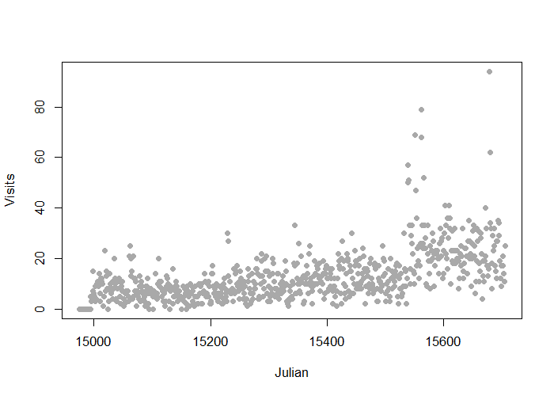

```r
plot(gaData$julian, gaData$visits, pch=19, col="darkgrey", xlab="Julian",
     ylab="Visits")
```

## Linear Regression

$$NH_i = b_0 + b_1 JD_i + e_i$$

$NH_i$ - number of hits to the website

$JD_i$ - day of the year (Julian day)

$b_0$ - number of hits on Julian day 0 (1970-01-01)

$b_1$ - increase in number of hits per unit day

$e_i$ - variation due to everything we didn’t measure

## Linear Regression Line

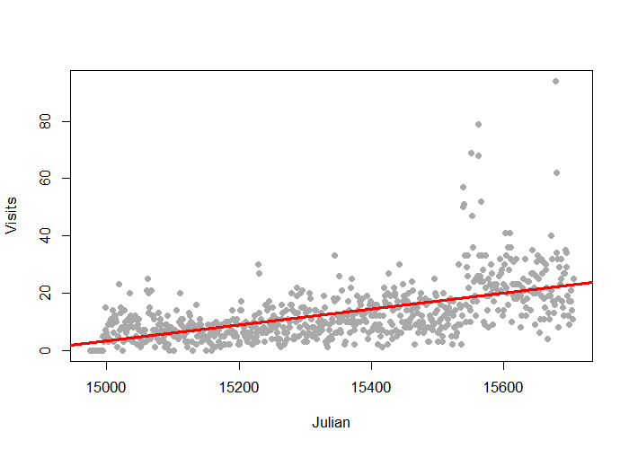

```r
plot(gaData$julian, gaData$visits, pch=19, col="darkgrey", xlab="Julian",
     ylab="Visits")
lm1 <- lm(gaData$visits ~ gaData$julian)
abline(lm1, col="red", lwd=3)
```

## Taking the Log of the Outcome

- Taking the natural log of the outcome has a specific interpretation
- Consider the model
  $$\log(NH_i) = b_0 + b_1 JD_i + e_i$$

$NH_i$ - number of hits to the website

$JD_i$ - day of the year (Julian day)

$b_0$ - log number of hits on Julian day 0 (1970-01-01)

$b_1$ - increase in log number of hits per unit day

$e_i$ - variation due to everything we didn’t measure

## Exponentiating Coefficients

```r
round(exp(coef(lm(I(log(gaData$visits + 1)) ~ gaData$julian))), 5)
```

```
  (Intercept) gaData$julian
      0.00000       1.00231
```

## Linear vs. Poisson Regression

**Linear**

$$NH_i = b_0 + b_1 JD_i + e_i$$

or

$$E[NH_i ~|~ JD_i,b_0,b_1] = b_0 + b_1 JD_i$$

**Poisson/log-linear**

$$\log(E[NH_i ~|~ JD_i,b_0,b_1]) = b_0 + b_1 JD_i$$

or

$$E[NH_i ~|~ JD_i,b_0,b_1] = e^{b_0 + b_1 JD_i}$$

## Multiplicative Differences

$$E[NH_i ~|~ JD_i,b_0,b_1] = e^{b_0 + b_1 JD_i}$$

$$E[NH_i ~|~ JD_i,b_0,b_1] = e^{b_0} e^{b_1 JD_i}$$

If $JD_i$ is increased by one unit, $E[NH_i ~|~ JD_i,b_0,b_1]$ is multiplied by $e^{b_1}$

## Poisson Regression in R

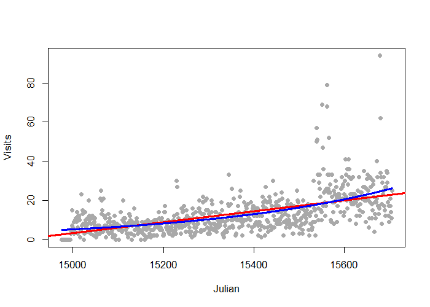

```r
plot(gaData$julian, gaData$visits, pch=19, col="darkgrey", xlab="Julian",
     ylab="Visits")
lm1 <- lm(gaData$visits ~ gaData$julian)
glm1 <- glm(gaData$visits ~ gaData$julian, poisson)
abline(lm1, col="red", lwd=3)
lines(gaData$julian, glm1$fitted, col="blue", lwd=3)
```

## Mean-Variance Relationship?

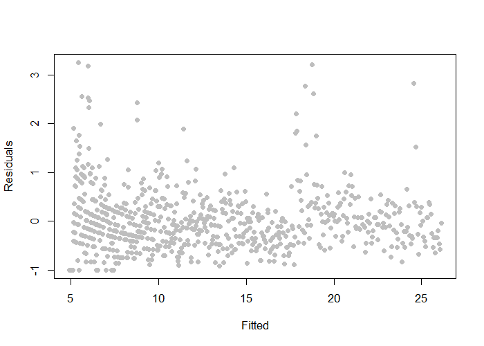

```r
plot(glm1$fitted, glm1$residuals, pch=19, col="grey", xlab="Fitted",
     ylab="Residuals")
```

## Model-Agnostic Standard Errors

```r
require(sandwich)
confint.agnostic <- function(object, parm, level=0.95, ...) {
    cf <- coef(object)
    pnames <- names(cf)
    if (missing(parm))
        parm <- pnames
    else if (is.numeric(parm))
        parm <- pnames[parm]
    a <- (1 - level) / 2
    a <- c(a, 1 - a)
    pct <- stats:::format.perc(a, 3)
    fac <- qnorm(a)
    ci <- array(NA, dim=c(length(parm), 2L), dimnames=list(parm, pct))
    ses <- sqrt(diag(sandwich::vcovHC(object)))[parm]
    ci [] <- cf[parm] + ses %o% fac
    ci
}
```

http://stackoverflow.com/questions/3817182/vcovhc-and-confidence-interval

## Estimating Confidence Intervals

```r
confint(glm1)
```

```
                      2.5 %        97.5 %
(Intercept)   -34.346577587 -31.159715656
gaData$julian   0.002190043   0.002396461
```

```r
confint.agnostic(glm1)
```

```
                      2.5 %        97.5 %
(Intercept)   -36.362674594 -29.136997254
gaData$julian   0.002058147   0.002527955
```

## Rates

$$E[NHSS_i ~|~ JD_i,b_0,b_1] / NH_i = e^{b_0 + b_1 JD_i}$$

$$\log(E[NHSS_i ~|~ JD_i,b_0,b_1]) - \log(NH_i) = b_0 + b_1 JD_i$$

$$\log(E[NHSS_i ~|~ JD_i,b_0,b_1]) = \log(NH_i) + b_0 + b_1 JD_i$$

## Fitting Rates in R

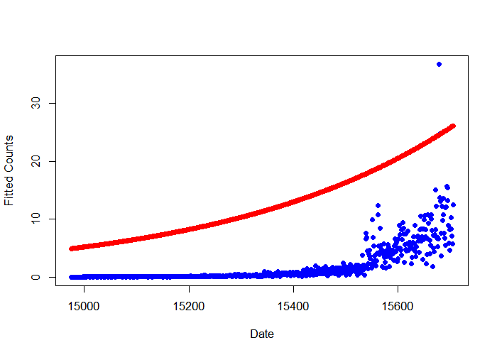

```r
glm2 <- glm(simplystats ~ julian(date), poisson, gaData, offset=log(visits + 1))
plot(julian(gaData$date), glm2$fitted, col="blue", pch=19, xlab="Date",
     ylab="Fitted Counts")
points(julian(gaData$date), glm1$fitted, col="red", pch=19)
```

## Fitting Rates in R

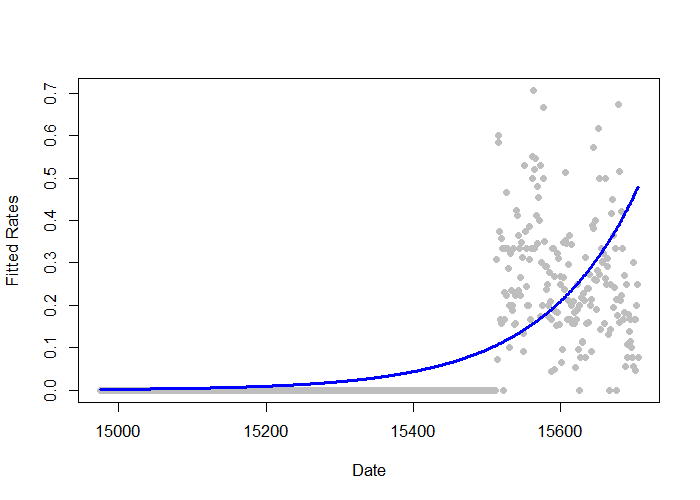

```r
plot(julian(gaData$date), gaData$simplystats / (gaData$visits + 1),
     col="grey", xlab="Date", ylab="Fitted Rates", pch=19)
lines(julian(gaData$date), glm2$fitted / (gaData$visits + 1), col="blue",
      lwd=3)
```

## More Information

- [Log-linear models and multiway tables](http://ww2.coastal.edu/kingw/statistics/R-tutorials/loglin.html)
- [Wikipedia on Poisson regression](https://en.wikipedia.org/wiki/Poisson_regression), [Wikipedia on overdispersion](https://en.wikipedia.org/wiki/Overdispersion)
- [Regression models for count data in R](https://cran.r-project.org/web/packages/pscl/vignettes/countreg.pdf)
- [pscl package](https://cran.r-project.org/web/packages/pscl/index.html) - the function `zeroinfl` fits zero inflated models